# Prosper Loan Analysis using R

### 2.4.6 Bank card utilization vs. Available Bankcard Credit

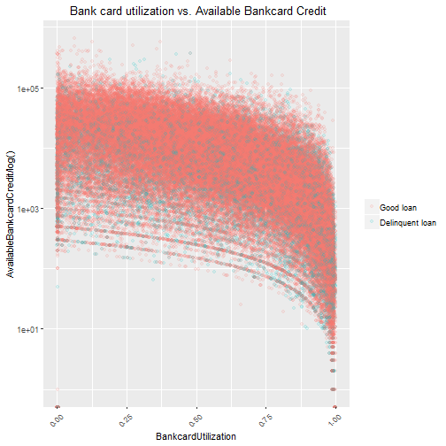

> Unexpectely,the bank card utilization and avilable band credit do not affect the borrower's deliquencies, by ploting the log value of the available credit, there was till no pattern showing strong correlation between the two variables.

### 2.4.7 Employment status vs. Borrower Rate

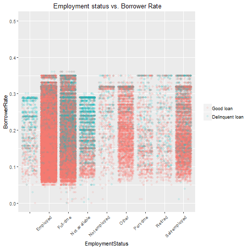

> The employment status of highly deliquent borrowers are unknown, but there is a clear trend that higher borrower rate would lead to high deliquencies.

### 2.4.8 Debt to income ratio vs. Loan amount

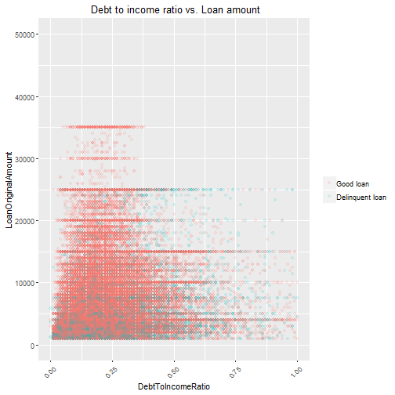

> Interestingly, deliquent borrowers are small loan borrowers. Also, deliquent borrowers tend to have higher Debt-to-income ratio.

### 2.4.9 Borrower rate vs. Loan amount

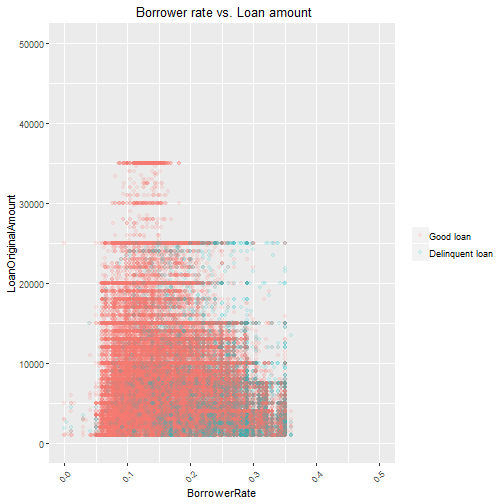

> Higher borrower rate tend to lead lower loan amount and higher deliquencies.

### 2.4.10 Borrower rate vs. monthly income

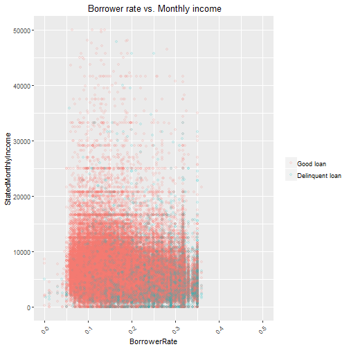

> Again, deliquent borrowers have lower onthly income and higher borrower rate.

### 2.4.11 Borrower rate vs. Debt-to-income ratio

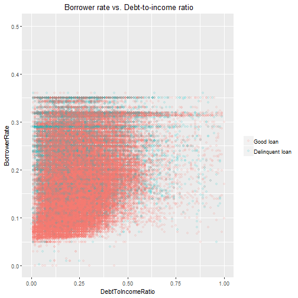

# Multivariate Analysis

> 1. Borrower rate is related to prosper score, higher borrower rate leads to lower Prosper score. Deliquent borrowers might due to higher borrower rate.
> 2. At the begining, I assumed employment status and loan purpose are two very important features that could help predict the default risk, however, there are large proportion of missing values for employment status and loan purpose.
> 3. Deliquent borrowers are small loan borrowers. Also, deliquent borrowers tend to have higher Debt-to-income ratio.

# Final Plots and Summary

### Plot One

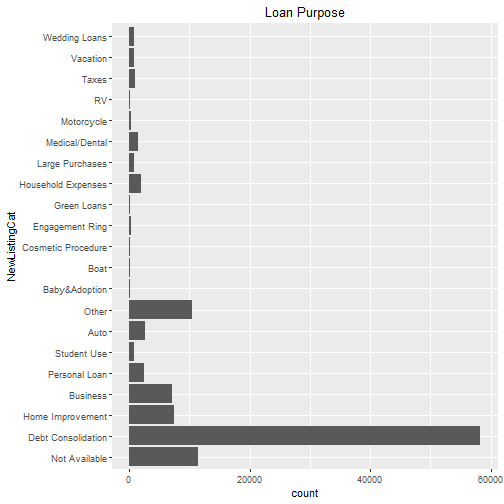

### Description One

> It is interesting to know that Debt Consolidation is the main purpose for loan borrowers. But we can als see from the plot that there is a large portion of loan purpose noted as 'other' and 'not available'. So we can remove these twoo categories to investigate the relation between deliquencies and loan purpose.

### Plot Two

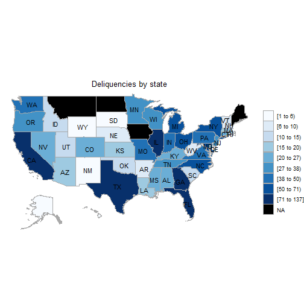

### Plot Three

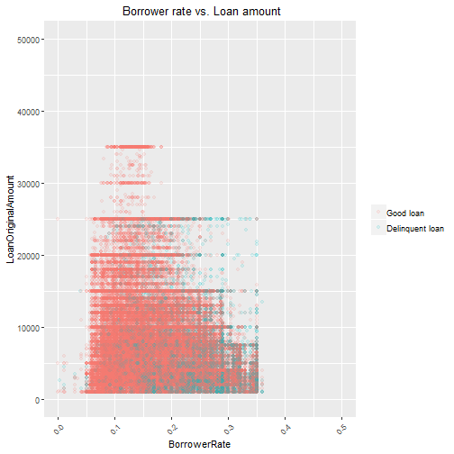

### Description Three

> There is strong evidence that higher borrower rate tend to lead higher deliquencies. So as investors, adjusting borower rate might increase the chance to collect the money back.

# Reflection

> 1. The prospser loans dataset contains over 100k observations with 81 variables spanning across 10 years.The first step before conducting any data analysis is to understand the variables, terminology and general domain knowledge of financial peer-to-peer lending.Second, it is very important to determine which variables to analyze and stick to those variables without drifting too far off.Also there are so many missing values and none specific observations, cleaning is needed for looking into the relationship between some variables.
> 2. For loan data, I believe that default risk analysis is a key component to help investors to decide if they could collect the full loan.So any features that could lead to default are worth investigating, In my analysis, I found that borrower rate from investor's aspect and Prosper score from borrower's aspect are strongly relatted to deliquencies. This brought me to investigate more features that could possibly affect borrower rate and prosper score, including monthly income, borrower region, loan purpose, employment status, credit card utilization, available credit, loan amount,home ownership, and debt to income ratio.

# Limitations

> The Exploratory Data Analysis strategy is a good way to find some insights of the date through interesting visualizations. However, EDA works better for data set with limited variables. For the Prosper Loan data with 81 variables, it is really time consuming to find out the most intesting features and investigate the correlations between them. In the future,an useful method to investigate this data could be building predictive models using machine learning.

# References

- 1. https://www.earthdatascience.org/courses/earth-analytics/time-series-data/summarize-time-series-by-month-in-r/
- 2. https://stackoverflow.com/questions/33221425/how-do-i-group-my-date-variable-into-month-year-in-r
- 3. https://www.r-bloggers.com/plot-weekly-or-monthly-totals-in-r/
- 4. https://github.com/cran/choroplethr/blob/master/R/choropleth.R
- 5. https://stackoverflow.com/questions/41376522/cregion-value-in-colnamesuser-df-are-not-all-true

[output not shown]

[output not shown]